# QIIME2R

Ninah

2026-06-04

## Set-up

It is important that you change your working directory for this Markdown, which can be found in the setup chunk, to the correct location as found on your system, before executing.

## Load libraries

Warning messages and outputs of this chunk are hidden, to view them, remove “message=FALSE” and results=‘hide’ from the chunk set-up.

```r
library(tidyverse)
library(vegan)
library(qiime2R)
library(phyloseq)
library(cowplot)
```

## Import data

```r
#Set wd
setwd("C:/Users/31040462/Desktop/Microbiomes/")
#Import QIIME2 artifacts into R; these objects need to be in your working directory, or specify their exact location by editing below
ps <- qza_to_phyloseq("Data/table.qza","Data/rooted-tree.qza","Data/taxonomy.qza","Data/sample-metadata.tsv")
```

```
## Warning in readLines(file, warn = readLines.warn): incomplete final line found
## on
## 'C:\Users\31040462\AppData\Local\Temp\RtmpWoA6wX/185f3105-190e-4a4c-a846-b765111b6d8d/metadata.yaml'
```

## Alpha diversity testing and plotting

```r
#This function for estimate_richness is from the phyloseq package
#See lesson notes for explanation of the warning that will be produced here
#It is not recommended to rely on richness-only estimates using data processed in DADA2, but rather those like Shannon/Simpson
#For the sake of teaching, we'll include richness estimates
alpha.ps <- estimate_richness(ps)
```

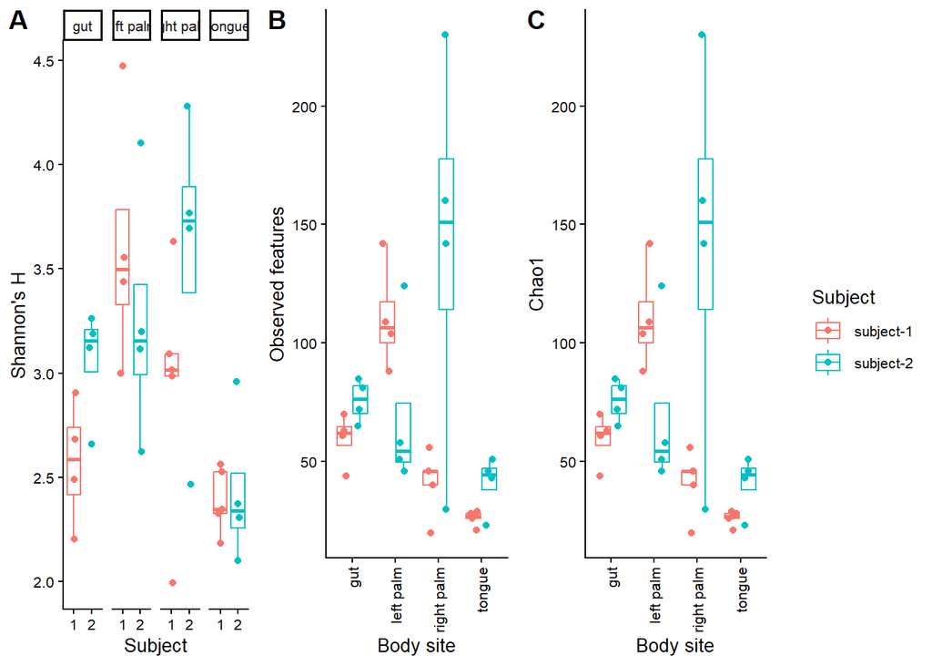

```r
#Export the results as a comma separated values file
write.csv(alpha.ps, "alpha-diversity-metrics.csv")

#Extract SampleIDs from the rownames of the alpha diversity & metadata
#Join the alpha diversity & metadata tables
alpha.ps$SampleID <- row.names(alpha.ps)
metadata.ps <- sample_data(ps)
metadata.ps$SampleID <- row.names(metadata.ps)
alpha.ps <- left_join(alpha.ps, metadata.ps,
                   by = "SampleID") %>% dplyr::select(1:12,16)

#These data could be further shaped to plot multiple variables at once, however:
#The diversity metric often have vastly different scales, so plotting separately and
#then joining them, might be the better option.
shannon.plot <- ggplot(alpha.ps, aes(x = subject, y = Shannon , colour = subject)) +
  geom_boxplot(outlier.shape = NA) +
  geom_jitter(shape=16, position=position_jitterdodge()) +
  facet_wrap(~ body.site, nrow = 1) +
  theme_classic() +
  labs(x="Subject", y = "Shannon's H", colour = "Subject") +
  scale_x_discrete(labels = c("subject-1" = "1", "subject-2" = "2")) +
  theme(text = element_text(size = 10),
        axis.text.x.bottom = element_text(),
        legend.position = "")


observed.plot <- ggplot(alpha.ps, aes(x = body.site, y = Observed , colour = subject)) +
  geom_boxplot(outlier.shape = NA) +
  geom_jitter(shape=16, position=position_jitterdodge()) +
  theme_classic() +
  labs(x="Body site", y = "Observed features", colour = "Subject") +
  theme(text = element_text(size = 10),
        axis.text.x.bottom = element_text(angle = 90,hjust = 1,vjust = 0.5),
        legend.position = "")

chao.plot <- ggplot(alpha.ps, aes(x = body.site, y = Chao1 , colour = subject)) +
  geom_boxplot(outlier.shape = NA) +
  geom_jitter(shape=16, position=position_jitterdodge()) +
  theme_classic() +
  labs(x="Body site", y = "Chao1", colour = "Subject") +
  theme(text = element_text(size = 10),
        axis.text.x.bottom = element_text(angle = 90,hjust = 1,vjust = 0.5))


#Arrange plots in grid & save into a .png
#ggsave has other options, explore the package to see what you can do
#dev.off() is included to close the plotting device after you are done with the plot
alpha.plots <- cowplot::plot_grid(shannon.plot, observed.plot, chao.plot + theme(legend.position="none"),
                        labels = c('A', 'B', 'C'),
                        label_size = 14, ncol = 3, nrow= 1)

legend <- get_legend(chao.plot + theme(legend.box.margin = margin(0, 0, 0, 12)))
plot_grid(alpha.plots, legend, rel_widths = c(3, .6))
```

```r
ggsave("C:/Users/31040462/Desktop/Microbiomes/Plots/alpha.plot.png", units = "cm", width = 15, height = 8, dpi = 300)
dev.off()
```

Self-study: The plot_richness function from phyloseq can also directly draw plots from the ps data

```r
ggsave("C:/Users/31040462/Desktop/Microbiomes/Plots/alpha.scatterplot.png", units = "cm", width = 15, height = 8, dpi = 300)
theme_set(theme_bw())
plot_richness(ps, x = "body.site", color = "subject",
                            measures = c("Observed", "Shannon")) +
                            labs(x="Body site", color = "Subject")
dev.off()
```

[output not shown]

## Alpha diversity statistical testing

```r
#Do statistical testing for the results
#Perform the Kruskal-Wallis tests, examples below are for Shannon & Observed features in Body sites
kw_shan <- kruskal.test(Shannon ~ body.site, data = alpha.ps)
kw_of <- kruskal.test(Observed ~ body.site, data = alpha.ps)

#Combine and export to csv
alpha_kw_all <- rbind(kw_shan, kw_of)
write.csv(alpha_kw_all, "alpha-stats-kw.csv", row.names = FALSE)
```

Self-study:If the Kruskal-Wallis test is significant where you have >2 groups, perform pairwise comparisons with multiple test correction. Tip: try Dunn’s test

```r
# make a plot that shows p-values; use kruskal-wallis tests
# Below is a function that can be adjusted

# First extract p-values
kw_shan$p.value
```

```
## [1] 0.002482203
```

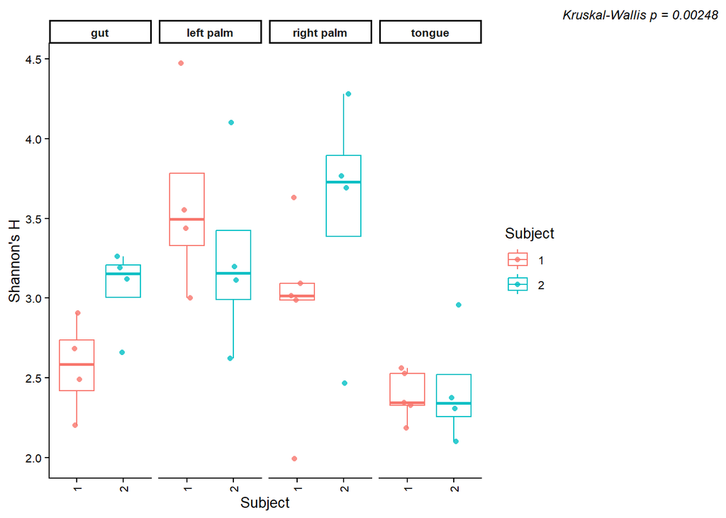

```r
# modify argument to accept p-values
plot_facet_stats <- function(data,metric = NULL,x_var = NULL,
                       facet_var = NULL,
                       y_label = NULL,
                       p_value = NULL,
                       output_file = NULL,
                       width = 20,height = 10,
                       units = "cm",dpi = 300) {
  if (is.null(y_label)) {
    y_label <- metric
  }
  if (is.null(output_file)) {
    output_file <- paste0("alpha_", metric, "_by_", x_var, "_facet_", facet_var, ".png")
  }
  data <- data %>% mutate(subject_clean = gsub("subject-", "", subject))

  #Plot
  p <- ggplot(data, aes(x = .data[[x_var]], y = .data[[metric]], colour = .data[[x_var]])) +
    geom_boxplot(outlier.shape = NA) +
    geom_jitter(
      shape = 16,width = 0.15,height = 0,alpha = 0.8) +
    facet_wrap(as.formula(paste("~", facet_var)), scales = "free_x", nrow = 1) +
    theme_classic() +
    labs(x = "Subject",y = y_label,colour = "Subject") +
    theme(text = element_text(size = 10),
      axis.text.x = element_text(angle = 90, hjust = 1, vjust = 0.5),
      legend.position = "right",
      strip.text = element_text(face = "bold"))

 if (!is.null(p_value)) {
  label <- paste0("Kruskal-Wallis p = ", signif(p_value, 3))

  p <- p + labs(tag = label) +
    theme(plot.tag = element_text(size = 9, face = "italic"),
          plot.tag.position = "topright")
}
  ggsave(filename = output_file,plot = p,
         width = width,height = height,
         units = units,dpi = dpi)
  return(p)
}

plot_facet_stats(data = alpha.ps,
          metric = "Shannon",
          x_var = "subject_clean",
          facet_var = "body.site",
          y_label = "Shannon's H",
          p_value = kw_shan$p.value,
          output_file = "C:/Users/31040462/Desktop/Microbiomes/Plots/shannon_subject_by_bodysite_stats.png")
```

## Beta diversity distance matrices and PCoA plots

The code chunk below explains how to produce beta-diversity distance (dissimilarity) matrices from a phyloseq object that was imported from QIIME2. First, the data is normalised to relative abundance per sample, whereafter the distance matrix (in this example, Bray-Curtis) and principal components and their percent variances are computed. These PCoA data are then plotted by a variable of interest.

```r
#Remove zeros if needed -below command will remove rows adding to zero, uncomment if required
#otu.table <- subset_taxa(ps, rowSums(otu_table(ps)) !=0 )

#Normalise for relative abundance table instead of absolute
#Instead of setting a function first, you could also just put the function terms directly in the transformSampleCounts(ps, function(x) x/sum(x))
normRelAb = function(x) { x/sum(x) }
relab.table = transformSampleCounts(ps, normRelAb) #normRelab (normalizing relative abundance), relab.table is the normRelab table

#For beta diversity, distance matrices have to be run separately
#Here we do Bray-Curtis; just for an example, "unifrac" & "wunifrac" will do unweighted/weighted UniFrac
#only one metric can be run at a time, so repeat as necessary
bray <- distance(relab.table, "bray")

#Do principal coordinates using cmdscale, where k is the number of PCos
# Perform PCoA with k = 10 as a test
bray.ktest <- cmdscale(bray, eig = TRUE, k = 10)  # k = 10 as a test

# Check eigenvalues (variance explained)
eigenvalues <- bray.ktest$eig
variance_explained <- eigenvalues / sum(eigenvalues) * 100  # Convert to percentage

# Print cumulative variance & choose k where the cumulative variance reaches at least ~70-80%
cumsum(variance_explained)
```

```
##  [1]  31.20554  52.82512  62.38433  69.17686  74.14433  78.27194  82.03400
##  [8]  85.40190  87.66808  89.66977  91.33915  92.74043  93.72084  94.63911
## [15]  95.43219  96.12259  96.75467  97.33685  97.81735  98.27815  98.66548
## [22]  98.98556  99.26921  99.51573  99.74352  99.91457 100.06073 100.14359
## [29] 100.17678 100.17678 100.17063 100.14503 100.10718 100.00000
```

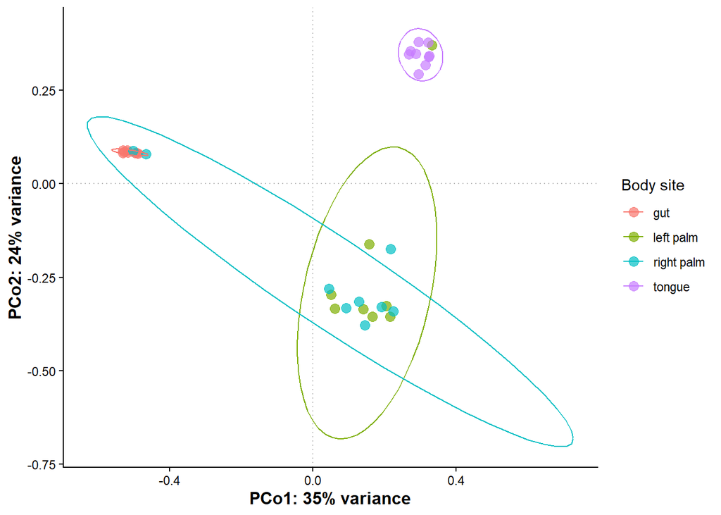

```r
# In this case, k = 10 is fine continue with braypco to add variance & percentvariance
# Re-run with new k if required, then add variance & percentvariance
braypco <- cmdscale(bray, k = 10)
brayVar <- apply(braypco, 2, var)
brayPercent <- round(100 * (brayVar/sum(brayVar)))

#Now add the metadata & rename the first 2 vectors as PCo1 & PCo2, as we will plot those
require(data.table)
brayTable <- merge(x = braypco, y = sample_data(relab.table), by = "row.names", all.x = TRUE)
colnames(brayTable)[colnames(brayTable)=="V1"] <- "PCo1"
colnames(brayTable)[colnames(brayTable)=="V2"] <- "PCo2"
colnames(brayTable)[colnames(brayTable)=="Row.names"] <- "name"

#Plot Bray-Curtis PCoA, with 95% conf ellipses
#You can change the plot axis limits, by uncommenting the coord_cartesian line
#Only do this once you have found the correct limits for your plot and adjust them in the line
#In this case, a plot that runs from -1 to 1 on both axes sufficiently cover all points & ellipses
ggplot(brayTable, aes(PCo1, PCo2, color= body.site)) +
  geom_point(size=3,alpha=0.7) +
  xlab(paste0("PCo1: ",brayPercent[1],"% variance")) +
  ylab(paste0("PCo2: ",brayPercent[2],"% variance")) +
  labs(color = "Body site") +
  theme_classic() +
  theme(axis.title=element_text(size=12,face="bold"), legend.position="right") +
  geom_hline(yintercept=0, linetype='dotted', col = 'grey') +
  geom_vline(xintercept=0, linetype='dotted', col = 'grey') +
  stat_ellipse(aes(group = body.site))
```

```r
# + coord_cartesian(xlim = c(-1, 1), ylim = c(-1, 1))

ggsave("C:/Users/31040462/Desktop/Microbiomes/Plots/BC.body.site.png", units= "px",dpi = 300)
dev.off()
```

Self-study: it is possible to do other plotting for groups, based on the centroids of the points. To generate centroids based on body site and add them to your datatable, try below & look up how you can use centroids to draw interesting plots!

```r
centroids <- aggregate(cbind(PCo1,PCo2)~body.site,data=brayTable, mean)
brayTable <- merge(brayTable,centroids,by="body.site",suffixes=c("",".centroid"))
```

## Beta diversity statistical testing

```r
#Do statistical testing by PERMANOVA of distance matrices to see significant differences
#Uses adonis2 from the "vegan" package
#Left side of the formula is a distance matrix, right side is the independent variables
bray.adonis <- adonis2(bray ~ sample_data(relab.table)$body.site)
write.csv(bray.adonis, "bray-curtis-adonis.csv")
```

Self-study: should you have >2 groups, and a significant result is achieved, a post-hoc test should be performed to determine which of the groups differ from each other. Tip: Try pairwise testing, such as Kruskal-Wallis, with multiple test correction